# PCOS Flagger: A Predictive System for Accessible Early Screening

(Milestone 2)

By: Nysa Bhat and Madeline Davis

link text[project website link](https://github.com/madelinefdavis/madelinefdavis.github.io)

# Project Goals

Our final project focuses on building a predictive model to determine whether an individual has Polycystic Ovary Syndrome (PCOS), a hormonal disorder affecting approximately 15% of women of reproductive age. PCOS is characterized by elevated androgen levels and symptoms such as irregular periods, acne, obesity, hair thinning, and infertility. While PCOS is not curable, its symptoms can be managed through medical and lifestyle interventions. The data set we are using can be found [here](https://www.kaggle.com/datasets/shreyasvedpathak/pcos-dataset/data) which we got from Kaggle. Using a dataset of 541 women collected via survey, which includes both PCOS diagnoses and clinical features, we aim to:

- Develop a classification model to predict PCOS based on symptom data.
- Identify the features most commonly associated with a PCOS diagnosis.

Our goal is to better understand which clinical indicators are most predictive of PCOS, providing a foundation for early screening and potential intervention strategies.

# Collaboration Plan

We will meet every Monday (zoom or in person). During this meeting we will come up with a task list for each of us to make sure we are making progress. When we have milestone due we will meet before we sumbit to go over our work and make sure it is cohesive

# 1. Load data/ETL

- Load data from .csv
- Address any missing information

```python
import pandas as pd

from google.colab import drive
drive.mount('/content/drive')
%cd /content/drive/MyDrive
```

```
/content/drive/MyDrive
```

```python
!jupyter nbconvert --to html "/content/drive/MyDrive/Colab Notebooks/project_milestone_2.ipynb"
```

[output not shown]

[output cut: 136 more lines]

[output not shown]

The steps down below will be summarized here: We began by loading the PCOS dataset (ideal_data) and cleaned it into a tidy format by removing irrelevant identifiers, handling missing values, and converting categorical variables (like blood_group) into numerical form using one-hot encoding. We also dropped features with low variance and low correlation to the target variable. One of the challenges was ensuring that all features were numeric so they could be used in machine learning models. By the end of this process, we had a well-structured dataset suitable for predictive modeling, with clearly defined input features and a binary target column (has_pcos).

Each step will take you through this with our PCOS dataset

```python
ideal_data = pd.read_csv('pcos_data.csv') #store the data in a dataframe
ideal_data.head() #display first five rows of data
```

|  | Sl. No | Patient File No. | has_pcos | Age (yrs) | Weight (Kg) | Height(Cm) | BMI | blood_group | Pulse_rate(bpm) | RR(breaths/min) | ... | has_pimples | eats_fast_food | does_exercise | BP _Systolic (mmHg) | BP _Diastolic (mmHg) | Follicle No. (L) | Follicle No. (R) | Avg. F size (L) (mm) | Avg. F size (R) (mm) | Endometrium (mm) |
| --- | --- | --- | --- | --- | --- | --- | --- | --- | --- | --- | --- | --- | --- | --- | --- | --- | --- | --- | --- | --- | --- |
| 0 | 1 | 1 | 0 | 28 | 44.6 | 152.0 | 19.300000 | O+ | 78 | 22 | ... | 0 | 1.0 | 0 | 110 | 80 | 3 | 3 | 18.0 | 18.0 | 8.5 |
| 1 | 2 | 2 | 0 | 36 | 65.0 | 161.5 | 24.921163 | O+ | 74 | 20 | ... | 0 | 0.0 | 0 | 120 | 70 | 3 | 5 | 15.0 | 14.0 | 3.7 |
| 2 | 3 | 3 | 1 | 33 | 68.8 | 165.0 | 25.270891 | A+ | 72 | 18 | ... | 1 | 1.0 | 0 | 120 | 80 | 13 | 15 | 18.0 | 20.0 | 10.0 |
| 3 | 4 | 4 | 0 | 37 | 65.0 | 148.0 | 29.674945 | B+ | 72 | 20 | ... | 0 | 0.0 | 0 | 120 | 70 | 2 | 2 | 15.0 | 14.0 | 7.5 |
| 4 | 5 | 5 | 0 | 25 | 52.0 | 161.0 | 20.060954 | A+ | 72 | 18 | ... | 0 | 0.0 | 0 | 120 | 80 | 3 | 4 | 16.0 | 14.0 | 7.0 |

5 rows × 44 columns

```python
ideal_data.shape # Display the number of rows and columns in the dataset (i.e., dataset dimensions)
```

```
(541, 44)
```

We dropped the identification columns since it is not useful for classification

```python
id_cols = ['Sl. No',
           'Patient File No.']
ideal_data.drop(columns=id_cols, axis=1, inplace=True)
# Drop identifier columns that do not contribute to prediction (e.g., serial number and file number)
```

```python
ideal_data.columns
# Display all column names in the dataset to review feature names after preprocessing
```

[output not shown]

We are dropping the following features because they are not realistically accessible during an initial or on-the-spot health assessment. If we were to deploy a PCOS prediction tool for users to input information themselves, we want to rely only on features that are simple, observable, or easily reported — such as symptoms, lifestyle, or basic vitals. Features like hormone levels (PRL, Vit_D3, I_beta-HCG), ultrasound results (Follicle No. and Endometrium), or detailed blood pressure readings require lab tests or clinical imaging, which may not be available to the average user without a medical visit. Including these would limit the practical use of the model for early or self-assessment.

```python
bad_features = ['No._of _abortions',
                'I_beta-HCG(mIU/mL)',
                'II_beta-HCG(mIU/mL)',
                'PRL(ng/mL)',
                'Vit_D3(ng/mL)',
                'BP _Systolic (mmHg)',
                'BP _Diastolic (mmHg)',
                'Follicle No. (L)',
                'Follicle No. (R)',
                'Avg. F size (L) (mm)',
                'Avg. F size (R) (mm)',
                'Endometrium (mm)'
                ]
ideal_data.drop(columns=bad_features, axis=1, inplace=True)
# Drop features that are irrelevant, contain excessive missing data, or have unclear clinical significance for PCOS prediction
```

```python
ideal_data.columns #store the data we want to keep
```

```
Index(['has_pcos', ' Age (yrs)', 'Weight (Kg)', 'Height(Cm) ', 'BMI',
       'blood_group', 'Pulse_rate(bpm) ', 'RR(breaths/min)', 'Hb(g/dl)',
       'Cycle(R/I)', 'Cycle_length(days)', 'Marriage_Status(Yrs)',
       'is_pregnant', 'FSH(mIU/mL)', 'LH(mIU/mL)', 'FSH/LH', 'Hip(inch)',
       'Waist(inch)', 'Waist:Hip Ratio', 'TSH (mIU/L)', 'AMH(ng/mL)',
       'PRG(ng/mL)', 'RBS(mg/dl)', 'has_weight_gain', 'has_hair_growth',
       'has_hyperpigmentation', 'has_hair_loss', 'has_pimples',
       'eats_fast_food', 'does_exercise'],
      dtype='object')
```

```python
ideal_data.isnull().sum()
# Check for missing values in each column to identify which features may need imputation or removal
```

|  | 0 |
| --- | --- |
| has_pcos | 0 |
| Age (yrs) | 0 |
| Weight (Kg) | 0 |
| Height(Cm) | 0 |
| BMI | 0 |
| blood_group | 0 |
| Pulse_rate(bpm) | 0 |
| RR(breaths/min) | 0 |
| Hb(g/dl) | 0 |
| Cycle(R/I) | 0 |
| Cycle_length(days) | 0 |
| Marriage_Status(Yrs) | 1 |
| is_pregnant | 0 |
| FSH(mIU/mL) | 0 |
| LH(mIU/mL) | 0 |
| FSH/LH | 0 |
| Hip(inch) | 0 |
| Waist(inch) | 0 |
| Waist:Hip Ratio | 0 |
| TSH (mIU/L) | 0 |
| AMH(ng/mL) | 0 |
| PRG(ng/mL) | 0 |
| RBS(mg/dl) | 0 |
| has_weight_gain | 0 |
| has_hair_growth | 0 |
| has_hyperpigmentation | 0 |
| has_hair_loss | 0 |
| has_pimples | 0 |
| eats_fast_food | 1 |
| does_exercise | 0 |

**dtype:** int64

```python
ideal_data[ideal_data.isnull().any(axis=1)]
```

|  | has_pcos | Age (yrs) | Weight (Kg) | Height(Cm) | BMI | blood_group | Pulse_rate(bpm) | RR(breaths/min) | Hb(g/dl) | Cycle(R/I) | ... | AMH(ng/mL) | PRG(ng/mL) | RBS(mg/dl) | has_weight_gain | has_hair_growth | has_hyperpigmentation | has_hair_loss | has_pimples | eats_fast_food | does_exercise |
| --- | --- | --- | --- | --- | --- | --- | --- | --- | --- | --- | --- | --- | --- | --- | --- | --- | --- | --- | --- | --- | --- |
| 156 | 0 | 27 | 53.2 | 158.0 | 21.3 | B+ | 72 | 22 | 10.5 | 4 | ... | 5.27 | 0.36 | 91.0 | 0 | 0 | 1 | 1 | 0 | NaN | 1 |
| 458 | 1 | 36 | 66.0 | 162.0 | 25.1 | O+ | 72 | 20 | 11.0 | 4 | ... | 6.6 | 0.25 | 93.0 | 0 | 0 | 0 | 0 | 0 | 0.0 | 0 |

2 rows × 30 columns

Two samples have missing information. At least one of them is missing a binary value, which would be difficult to impute. Drop them.

```python
ideal_data.dropna(inplace=True)
ideal_data.shape
#drop missing data, and now provide the new row/column
```

```
(539, 30)
```

```python
ideal_data.dtypes #display datatypes for each feature
```

|  | 0 |
| --- | --- |
| has_pcos | int64 |
| Age (yrs) | int64 |
| Weight (Kg) | float64 |
| Height(Cm) | float64 |
| BMI | float64 |
| blood_group | object |
| Pulse_rate(bpm) | int64 |
| RR(breaths/min) | int64 |
| Hb(g/dl) | float64 |
| Cycle(R/I) | int64 |
| Cycle_length(days) | int64 |
| Marriage_Status(Yrs) | float64 |
| is_pregnant | int64 |
| FSH(mIU/mL) | float64 |
| LH(mIU/mL) | float64 |
| FSH/LH | float64 |
| Hip(inch) | int64 |
| Waist(inch) | int64 |
| Waist:Hip Ratio | float64 |
| TSH (mIU/L) | float64 |
| AMH(ng/mL) | object |
| PRG(ng/mL) | float64 |
| RBS(mg/dl) | float64 |
| has_weight_gain | int64 |
| has_hair_growth | int64 |
| has_hyperpigmentation | int64 |
| has_hair_loss | int64 |
| has_pimples | int64 |
| eats_fast_food | float64 |
| does_exercise | int64 |

**dtype:** object

Here, we see that blood_group is categorical. We can address this via one-hot encoding.

```python
ideal_data = pd.get_dummies(ideal_data, columns=["blood_group"], dtype=int)
ideal_data
#did one hot encoding to covert blood type to numerical values
```

|  | has_pcos | Age (yrs) | Weight (Kg) | Height(Cm) | BMI | Pulse_rate(bpm) | RR(breaths/min) | Hb(g/dl) | Cycle(R/I) | Cycle_length(days) | ... | eats_fast_food | does_exercise | blood_group_A+ | blood_group_A- | blood_group_AB+ | blood_group_AB- | blood_group_B+ | blood_group_B- | blood_group_O+ | blood_group_O- |
| --- | --- | --- | --- | --- | --- | --- | --- | --- | --- | --- | --- | --- | --- | --- | --- | --- | --- | --- | --- | --- | --- |
| 0 | 0 | 28 | 44.6 | 152.000 | 19.300000 | 78 | 22 | 10.48 | 2 | 5 | ... | 1.0 | 0 | 0 | 0 | 0 | 0 | 0 | 0 | 1 | 0 |
| 1 | 0 | 36 | 65.0 | 161.500 | 24.921163 | 74 | 20 | 11.70 | 2 | 5 | ... | 0.0 | 0 | 0 | 0 | 0 | 0 | 0 | 0 | 1 | 0 |
| 2 | 1 | 33 | 68.8 | 165.000 | 25.270891 | 72 | 18 | 11.80 | 2 | 5 | ... | 1.0 | 0 | 1 | 0 | 0 | 0 | 0 | 0 | 0 | 0 |
| 3 | 0 | 37 | 65.0 | 148.000 | 29.674945 | 72 | 20 | 12.00 | 2 | 5 | ... | 0.0 | 0 | 0 | 0 | 0 | 0 | 1 | 0 | 0 | 0 |
| 4 | 0 | 25 | 52.0 | 161.000 | 20.060954 | 72 | 18 | 10.00 | 2 | 5 | ... | 0.0 | 0 | 1 | 0 | 0 | 0 | 0 | 0 | 0 | 0 |
| ... | ... | ... | ... | ... | ... | ... | ... | ... | ... | ... | ... | ... | ... | ... | ... | ... | ... | ... | ... | ... | ... |
| 536 | 0 | 35 | 50.0 | 164.592 | 18.500000 | 72 | 16 | 11.00 | 2 | 5 | ... | 0.0 | 0 | 0 | 0 | 1 | 0 | 0 | 0 | 0 | 0 |
| 537 | 0 | 30 | 63.2 | 158.000 | 25.300000 | 72 | 18 | 10.80 | 2 | 5 | ... | 0.0 | 0 | 0 | 0 | 0 | 0 | 0 | 0 | 1 | 0 |
| 538 | 0 | 36 | 54.0 | 152.000 | 23.400000 | 74 | 20 | 10.80 | 2 | 6 | ... | 0.0 | 0 | 0 | 0 | 0 | 0 | 1 | 0 | 0 | 0 |
| 539 | 0 | 27 | 50.0 | 150.000 | 22.200000 | 74 | 20 | 12.00 | 4 | 2 | ... | 0.0 | 0 | 0 | 0 | 0 | 0 | 0 | 0 | 1 | 0 |
| 540 | 1 | 23 | 82.0 | 165.000 | 30.100000 | 80 | 20 | 10.20 | 4 | 7 | ... | 1.0 | 0 | 0 | 0 | 0 | 0 | 1 | 0 | 0 | 0 |

539 rows × 37 columns

From the column dtypes, it also seems that AMH(ng/mL) may have some non-numeric values. Let's explore this.

```python
ideal_data[pd.to_numeric(ideal_data['AMH(ng/mL)'], errors='coerce').isna()]
# Identify rows where the 'AMH(ng/mL)' column contains non-numeric values (e.g., strings, missing data).
# Converts the column to numeric, coercing errors to NaN, then filters rows where the result is NaN.
```

|  | has_pcos | Age (yrs) | Weight (Kg) | Height(Cm) | BMI | Pulse_rate(bpm) | RR(breaths/min) | Hb(g/dl) | Cycle(R/I) | Cycle_length(days) | ... | eats_fast_food | does_exercise | blood_group_A+ | blood_group_A- | blood_group_AB+ | blood_group_AB- | blood_group_B+ | blood_group_B- | blood_group_O+ | blood_group_O- |
| --- | --- | --- | --- | --- | --- | --- | --- | --- | --- | --- | --- | --- | --- | --- | --- | --- | --- | --- | --- | --- | --- |
| 305 | 0 | 37 | 56.0 | 152.0 | 24.238227 | 74 | 20 | 11.7 | 2 | 5 | ... | 0.0 | 1 | 0 | 0 | 0 | 0 | 1 | 0 | 0 | 0 |

1 rows × 37 columns

```python
print(ideal_data[pd.to_numeric(ideal_data['AMH(ng/mL)'], errors='coerce').isna()].values)
print(ideal_data['AMH(ng/mL)'][305])
print('AMH(ng/mL) column average:', pd.to_numeric(ideal_data['AMH(ng/mL)'], errors='coerce').mean())
```

```
[[0 37 56.0 152.0 24.23822715 74 20 11.7 2 5 9.0 0 2.91 0.35 8.314285714
  35 33 0.942857143 16.0 'a' 0.3 100.0 0 0 0 0 1 0.0 1 0 0 0 0 1 0 0 0]]
a
AMH(ng/mL) column average: 5.62303531598513
```

Sure enough, row 305 has an 'a' in the AMH(ng/mL) column. We could address this by replacing this value with the column mean via imputing...

```python
from sklearn.impute import SimpleImputer

test = ideal_data.copy()
test.replace('a',np.nan,inplace=True)
imp_mean = SimpleImputer(missing_values=np.nan, strategy='mean')
test = pd.DataFrame(imp_mean.fit_transform(test), columns=test.columns, index=test.index)
print('New value:', test['AMH(ng/mL)'][305])
```

```
New value: 5.62303531598513
```

BUT this is an example of data leakage, as we are using information from the entire dataset (mean) to address a single value which will later be partitioned into the train or test set. Instead, it is easier to just drop it.

```python
ideal_data.drop(index=305, inplace=True)
```

```python
print('samples with pcos:',ideal_data[ideal_data['has_pcos']==1].shape[0])
print('samples without pcos:',ideal_data[ideal_data['has_pcos']==0].shape[0])
```

```
samples with pcos: 176
samples without pcos: 362
```

We have a notable class imbalance. We will have to address this when training the models.

# 2. Train baseline model 1 (all features, without feature selection) EDA

```python
from sklearn.model_selection import train_test_split

X = ideal_data.drop(columns=['has_pcos'], axis=1).values
y = ideal_data['has_pcos'].values
X_train, X_test, y_train, y_test = train_test_split(X, y, test_size=0.3, random_state=42)

print('X_train:',X_train.shape)
print('y_train:',y_train.shape)
print('X_test:',X_test.shape)
print('y_test:',y_test.shape)
```

```
X_train: (376, 36)
y_train: (376,)
X_test: (162, 36)
y_test: (162,)
```

While some classifiers do not require scaling, we should scale our data to make best use of certain classifiers.

```python
from sklearn.preprocessing import MinMaxScaler

scaler = MinMaxScaler()
# Only fit scaler to X_train to prevent data leakage
scaler.fit(X_train)
X_train=scaler.transform(X_train)
X_test=scaler.transform(X_test)
```

```python
from sklearn.linear_model import LogisticRegression
from sklearn.ensemble import RandomForestClassifier
from sklearn.neighbors import KNeighborsClassifier
from sklearn.metrics import accuracy_score, precision_score, recall_score, f1_score, roc_auc_score, brier_score_loss

# Define models
models = [
    ('Logistic Regression', LogisticRegression(random_state=42)),
    ('Random Forest', RandomForestClassifier(random_state=42)),
    ('K Nearest Neighbors', KNeighborsClassifier()), # Added KNN
]

# Train and evaluate models
results = []
for name, model in models:
    model.fit(X_train, y_train)
    y_pred = model.predict(X_test)

    # Calculate metrics
    accuracy = accuracy_score(y_test, y_pred)
    precision = precision_score(y_test, y_pred)
    recall = recall_score(y_test, y_pred)
    f1 = f1_score(y_test, y_pred)
    roc_auc = roc_auc_score(y_test, y_pred)
    brier_score = brier_score_loss(y_test, y_pred)
    fpr = 1 - recall_score(y_test, y_pred, pos_label=0) # False Positive Rate

    results.append([name, accuracy, precision, recall, f1, roc_auc, fpr, brier_score])

# Create DataFrame for results
base_1_metrics = pd.DataFrame(results, columns=['Name', 'Accuracy', 'Precision', 'Recall', 'F1', 'ROC AUC', 'FPR', 'Brier Score'])

# Now you can save the results to CSV
base_1_metrics.to_csv('no_scale_base_metrics.csv', index=False)
base_1_metrics
```

|  | Name | Accuracy | Precision | Recall | F1 | ROC AUC | FPR | Brier Score |
| --- | --- | --- | --- | --- | --- | --- | --- | --- |
| 0 | Logistic Regression | 0.839506 | 0.782609 | 0.692308 | 0.734694 | 0.800699 | 0.090909 | 0.160494 |
| 1 | Random Forest | 0.802469 | 0.727273 | 0.615385 | 0.666667 | 0.753147 | 0.109091 | 0.197531 |
| 2 | K Nearest Neighbors | 0.796296 | 0.743590 | 0.557692 | 0.637363 | 0.733392 | 0.090909 | 0.203704 |

We implemented three predictive modeling techniques — Logistic Regression, Random Forest, and K-Nearest Neighbors (KNN) — to classify individuals as having PCOS or not. To evaluate model performance, we used several metrics: Accuracy, Recall, Precision, F1 Score, ROC AUC, False Positive Rate (FPR), and Brier Score.

Logistic Regression consistently performed the best overall, achieving the highest scores in most metrics including Accuracy, ROC AUC, and F1 Score, indicating strong balanced performance.

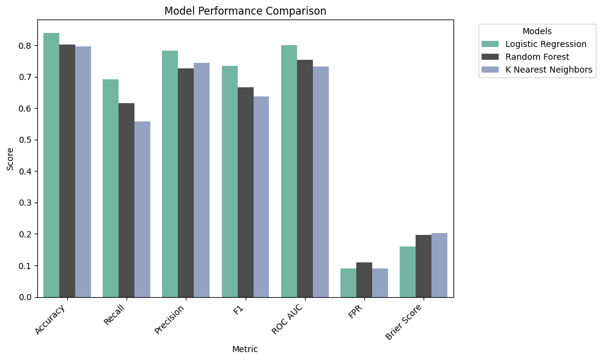

```python
import matplotlib.pyplot as plt
import seaborn as sns

def plot_model_performance(df):
    """
    Create a simplified grouped bar plot to visualize model performance metrics.

    Parameters:
    df (pandas.DataFrame): DataFrame containing model performance metrics
    """
    # Metrics to plot
    metrics = ['Accuracy', 'Recall', 'Precision', 'F1', 'ROC AUC', 'FPR', 'Brier Score']

    # Melt the dataframe to create a long-format dataframe
    df_melted = df.melt(id_vars='Name', value_vars=metrics, var_name='Metric', value_name='Score')

    # Set up the plot
    plt.figure(figsize=(10, 6))

    # Create a custom color palette
    custom_palette = sns.color_palette("Set2")  # Use Set2 palette for distinct colors
    custom_palette[df['Name'].tolist().index('Random Forest')] = (0.3, 0.3, 0.3) # Set Random Forest to dark grey

    # Create the plot using Seaborn
    sns.barplot(
        x='Metric',
        y='Score',
        hue='Name',
        data=df_melted,
        palette=custom_palette
    )

    # Customize the plot
    plt.title('Model Performance Comparison')
    plt.xticks(rotation=45, ha='right')
    plt.legend(title='Models', bbox_to_anchor=(1.05, 1), loc='upper left')
    plt.tight_layout()

    # Show the plot
    plt.show()

plot_model_performance(base_1_metrics)
```

# 3 Feature Selection

We are performing feature selection to identify the most relevant variables that contribute to predicting whether someone has PCOS. In the previous section, we trained models using all available features in the dataset. While this can be useful as a baseline, it often includes noisy, redundant, or irrelevant data that may reduce model performance or lead to overfitting. By removing the target variable has_pcos and focusing on the remaining features in X_df, we can:

- Train models on a cleaner, more focused dataset
- Improve interpretability by highlighting which features are most predictive - Reduce computational complexity
- Potentially boost model generalization to new data

This process allows us to better understand which clinical indicators are most strongly associated with PCOS and supports the development of a more streamlined, accurate predictive model.

```python
X_df = ideal_data.drop(columns=['has_pcos'], axis=1)
y_df = ideal_data['has_pcos']
X_train_df, X_test_df, y_train_df, y_test_df = train_test_split(X_df, y_df, test_size=0.3, random_state=42)

print('X_train:',X_train_df.shape)
print('y_train:',y_train_df.shape)
print('X_test:',X_test_df.shape)
print('y_test:',y_test_df.shape)
```

```
X_train: (376, 36)
y_train: (376,)
X_test: (162, 36)
y_test: (162,)
```

We used .describe().T.sort_values(by='std') to examine the statistical distribution of each feature in the training set, focusing on standard deviation. This helps us understand which features have the most variability across the dataset — a key factor in identifying informative predictors. Features with very low standard deviation may have little discriminative power and can potentially be removed during feature selection.

```python
X_train_df.describe().T.sort_values(by='std')
```

|  | count | mean | std | min | 25% | 50% | 75% | max |
| --- | --- | --- | --- | --- | --- | --- | --- | --- |
| Waist:Hip Ratio | 376.0 | 0.890910 | 0.047043 | 0.761905 | 0.857143 | 0.894737 | 0.929762 | 0.979167 |
| blood_group_AB- | 376.0 | 0.002660 | 0.051571 | 0.000000 | 0.000000 | 0.000000 | 0.000000 | 1.000000 |
| blood_group_A- | 376.0 | 0.023936 | 0.153054 | 0.000000 | 0.000000 | 0.000000 | 0.000000 | 1.000000 |
| blood_group_B- | 376.0 | 0.026596 | 0.161113 | 0.000000 | 0.000000 | 0.000000 | 0.000000 | 1.000000 |
| blood_group_O- | 376.0 | 0.034574 | 0.182943 | 0.000000 | 0.000000 | 0.000000 | 0.000000 | 1.000000 |
| blood_group_AB+ | 376.0 | 0.069149 | 0.254045 | 0.000000 | 0.000000 | 0.000000 | 0.000000 | 1.000000 |
| blood_group_A+ | 376.0 | 0.199468 | 0.400133 | 0.000000 | 0.000000 | 0.000000 | 0.000000 | 1.000000 |
| does_exercise | 376.0 | 0.247340 | 0.432041 | 0.000000 | 0.000000 | 0.000000 | 0.000000 | 1.000000 |
| blood_group_B+ | 376.0 | 0.255319 | 0.436621 | 0.000000 | 0.000000 | 0.000000 | 1.000000 | 1.000000 |
| has_hair_growth | 376.0 | 0.276596 | 0.447911 | 0.000000 | 0.000000 | 0.000000 | 1.000000 | 1.000000 |
| has_hyperpigmentation | 376.0 | 0.308511 | 0.462494 | 0.000000 | 0.000000 | 0.000000 | 1.000000 | 1.000000 |
| blood_group_O+ | 376.0 | 0.388298 | 0.488012 | 0.000000 | 0.000000 | 0.000000 | 1.000000 | 1.000000 |
| has_weight_gain | 376.0 | 0.390957 | 0.488615 | 0.000000 | 0.000000 | 0.000000 | 1.000000 | 1.000000 |
| is_pregnant | 376.0 | 0.398936 | 0.490332 | 0.000000 | 0.000000 | 0.000000 | 1.000000 | 1.000000 |
| has_hair_loss | 376.0 | 0.465426 | 0.499468 | 0.000000 | 0.000000 | 0.000000 | 1.000000 | 1.000000 |
| has_pimples | 376.0 | 0.521277 | 0.500213 | 0.000000 | 0.000000 | 1.000000 | 1.000000 | 1.000000 |
| eats_fast_food | 376.0 | 0.515957 | 0.500411 | 0.000000 | 0.000000 | 1.000000 | 1.000000 | 1.000000 |
| Hb(g/dl) | 376.0 | 11.184335 | 0.858237 | 8.500000 | 10.500000 | 11.000000 | 11.800000 | 14.800000 |
| Cycle(R/I) | 376.0 | 2.550532 | 0.898947 | 2.000000 | 2.000000 | 2.000000 | 4.000000 | 5.000000 |
| Cycle_length(days) | 376.0 | 4.960106 | 1.489878 | 2.000000 | 5.000000 | 5.000000 | 6.000000 | 12.000000 |
| RR(breaths/min) | 376.0 | 19.289894 | 1.746159 | 16.000000 | 18.000000 | 18.000000 | 20.000000 | 28.000000 |
| LH(mIU/mL) | 376.0 | 2.692106 | 2.229287 | 0.020000 | 1.007500 | 2.280000 | 3.612500 | 14.690000 |
| Waist(inch) | 376.0 | 33.728723 | 3.522245 | 24.000000 | 32.000000 | 34.000000 | 36.000000 | 47.000000 |
| Hip(inch) | 376.0 | 37.912234 | 3.900121 | 26.000000 | 36.000000 | 38.000000 | 40.000000 | 48.000000 |
| Pulse_rate(bpm) | 376.0 | 73.215426 | 4.035691 | 13.000000 | 72.000000 | 72.000000 | 74.000000 | 82.000000 |
| BMI | 376.0 | 24.301822 | 4.112859 | 12.417882 | 21.900000 | 24.400000 | 26.411228 | 38.900000 |
| TSH (mIU/L) | 376.0 | 3.118226 | 4.251473 | 0.040000 | 1.510000 | 2.285000 | 3.642500 | 65.000000 |
| PRG(ng/mL) | 376.0 | 0.631306 | 4.380906 | 0.047000 | 0.250000 | 0.310000 | 0.450000 | 85.000000 |
| Marriage_Status(Yrs) | 376.0 | 7.761170 | 4.896718 | 1.000000 | 4.000000 | 7.000000 | 11.000000 | 30.000000 |
| Age (yrs) | 376.0 | 31.454787 | 5.380268 | 20.000000 | 27.000000 | 31.000000 | 35.000000 | 48.000000 |
| Height(Cm) | 376.0 | 156.400426 | 5.881315 | 137.000000 | 152.000000 | 156.000000 | 160.000000 | 180.000000 |
| Weight (Kg) | 376.0 | 59.536702 | 11.001056 | 31.000000 | 52.000000 | 60.000000 | 65.000000 | 104.000000 |
| RBS(mg/dl) | 376.0 | 99.545745 | 15.333680 | 60.000000 | 92.000000 | 100.000000 | 107.000000 | 225.000000 |
| FSH/LH | 376.0 | 8.280657 | 72.708295 | 0.416944 | 1.443450 | 2.204917 | 4.121646 | 1372.826087 |
| FSH(mIU/mL) | 376.0 | 18.819266 | 260.309577 | 1.000000 | 3.350000 | 4.815000 | 6.400000 | 5052.000000 |

We dropped the 'Waist:Hip Ratio' feature from both the training and test sets due to its extremely low variance. Features with little to no variation provide minimal predictive value and can negatively impact model performance. Removing them helps reduce noise and simplify the model.

```python
low_var_cols = ['Waist:Hip Ratio']  # Only keep the 'Waist:Hip Ratio' column for now

for col in low_var_cols:
    if col in X_train_df.columns:  # Check if the column exists before dropping
        X_train_df.drop(columns=[col], inplace=True)
    if col in X_test_df.columns:  # Check if the column exists before dropping
        X_test_df.drop(columns=[col], inplace=True)
```

We generated this correlation matrix to explore the relationships between different numerical features in our dataset. This helps us identify highly correlated variables, which can be redundant and potentially harm model performance due to multicollinearity. It also allows us to uncover which clinical or behavioral indicators are associated with each other — for example, we observed strong positive correlations between weight-related variables (like BMI, Waist, and Hip measurements), which is expected. This analysis guides our feature selection process by highlighting features that provide unique and relevant information.

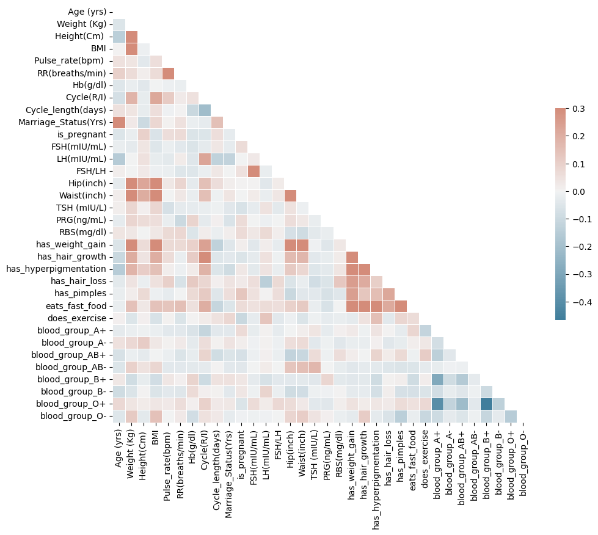

```python
# Step 1: Keep only numeric columns for correlation
numeric_df = X_train_df.select_dtypes(include=['float64', 'int64'])

# Step 2: Compute the correlation matrix
corr = numeric_df.corr()

# Step 3: Generate a mask for the upper triangle
mask = np.triu(np.ones_like(corr, dtype=bool))

# Step 4: Set up the matplotlib figure
f, ax = plt.subplots(figsize=(11, 9))

# Step 5: Generate a custom diverging colormap
cmap = sns.diverging_palette(230, 20, as_cmap=True)

# Step 6: Draw the heatmap
sns.heatmap(corr, mask=mask, cmap=cmap, vmax=0.3, center=0,
            square=True, linewidths=0.5, cbar_kws={"shrink": 0.5})
```

We generated this heatmap to visualize the correlation between each feature and the target variable has_pcos. This helps us identify which features are most strongly associated with a PCOS diagnosis. Features such as has_hyperpigmentation, has_hair_growth, has_weight_gain, and eats_fast_food show the highest positive correlations, suggesting they may be important indicators for prediction. By sorting features based on their absolute correlation values, we can prioritize the most relevant features during model training and feature selection.

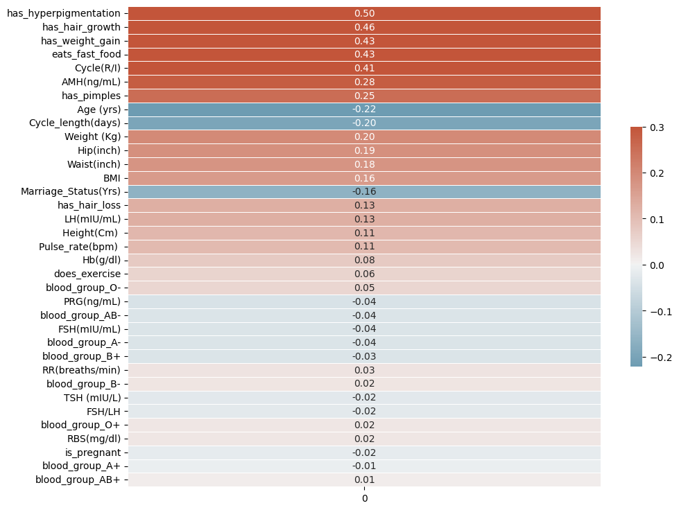

```python
# Compute the correlation matrix
corrwith = X_train_df.corrwith(y_train_df)

# Set up the matplotlib figure
f, ax = plt.subplots(figsize=(11, 9))

# Generate a custom diverging colormap
cmap = sns.diverging_palette(230, 20, as_cmap=True)

# Draw the heatmap with annotations
sns.heatmap(
    pd.DataFrame(corrwith).sort_values(by=0, key=abs, ascending=False),
    cmap=cmap,
    vmax=.3,
    center=0,
    linewidths=.5,
    cbar_kws={"shrink": .5},
    annot=True,  # Annotate the heatmap with correlation values
    fmt=".2f"    # Format the annotation with two decimal points

)
```

This histogram was created to show the overall distribution of correlation strengths between individual features and the PCOS diagnosis variable. Unlike the previous heatmap, which visualized correlations for each specific feature, this plot gives us a summary view of how many features fall into different correlation ranges. It helps answer the question: “How informative is the dataset overall?” From the plot, we can see that most features have very low correlation values, meaning only a small subset of features may be significantly useful for prediction. This broader statistical overview supports decisions about dimensionality reduction and setting correlation-based thresholds for feature filtering.

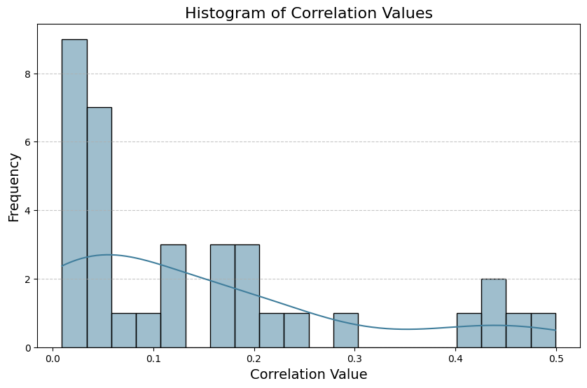

```python
# Generate the custom diverging colormap
cmap = sns.diverging_palette(230, 20, as_cmap=False)  # `as_cmap=False` returns a list of colors

# Extract the values from the DataFrame and flatten them

# Set up the matplotlib figure
plt.figure(figsize=(10, 6))

# Plot the histogram
sns.histplot(corrwith.abs(), bins=20, kde=True, color=cmap[0], edgecolor="black")

# Customize the plot
plt.title("Histogram of Correlation Values", fontsize=16)
plt.xlabel("Correlation Value", fontsize=14)
plt.ylabel("Frequency", fontsize=14)
plt.grid(axis='y', linestyle='--', alpha=0.7)
```

We dropped features that had very low correlation with the PCOS diagnosis to streamline our dataset and retain only variables that may contribute meaningful predictive value.

```python
low_corrwith_cols = ['blood_group_B+', 'blood_group_A+', 'blood_group_O+', 'RR(breaths/min)', 'TSH (mIU/L)', 'FSH/LH','RBS(mg/dl)','is_pregnant']
X_train_df.drop(columns=low_corrwith_cols, inplace=True)
X_test_df.drop(columns=low_corrwith_cols, inplace=True)
```

# 4 Train model (w/ feature selection)

```python
X_train = X_train_df.values
X_test = X_test_df.values
y_train = y_train_df.values
y_test = y_test_df.values
```

```python
scaler = MinMaxScaler()
# Only fit scaler to X_train to prevent data leakage
scaler.fit(X_train)
X_train=scaler.transform(X_train)
X_test=scaler.transform(X_test)
```

After performing feature selection to remove low-variance and low-correlation features, we retrained our models — Logistic Regression, Random Forest, and K-Nearest Neighbors — on the refined dataset. This updated performance comparison helps us assess how model accuracy and reliability changed after reducing noise and dimensionality.

```python
# Define models
models = [
    ('Logistic Regression', LogisticRegression(random_state=42)),
    ('Random Forest', RandomForestClassifier(random_state=42)),
    ('K Nearest Neighbors', KNeighborsClassifier()), # Added KNN
]

# Train and evaluate models
results = []
for name, model in models:
    model.fit(X_train, y_train)
    y_pred = model.predict(X_test)

    # Calculate metrics
    accuracy = accuracy_score(y_test, y_pred)
    precision = precision_score(y_test, y_pred)
    recall = recall_score(y_test, y_pred)
    f1 = f1_score(y_test, y_pred)
    roc_auc = roc_auc_score(y_test, y_pred)
    brier_score = brier_score_loss(y_test, y_pred)
    fpr = 1 - recall_score(y_test, y_pred, pos_label=0) # False Positive Rate

    results.append([name, accuracy, precision, recall, f1, roc_auc, fpr, brier_score])

# Create DataFrame for results
ideal_metrics = pd.DataFrame(results, columns=['Name', 'Accuracy', 'Precision', 'Recall', 'F1', 'ROC AUC', 'FPR', 'Brier Score'])

# Now you can save the results to CSV
ideal_metrics.to_csv('ideal_metrics.csv', index=False)
ideal_metrics
```

|  | Name | Accuracy | Precision | Recall | F1 | ROC AUC | FPR | Brier Score |
| --- | --- | --- | --- | --- | --- | --- | --- | --- |
| 0 | Logistic Regression | 0.851852 | 0.804348 | 0.711538 | 0.755102 | 0.814860 | 0.081818 | 0.148148 |
| 1 | Random Forest | 0.802469 | 0.738095 | 0.596154 | 0.659574 | 0.748077 | 0.100000 | 0.197531 |
| 2 | K Nearest Neighbors | 0.833333 | 0.765957 | 0.692308 | 0.727273 | 0.796154 | 0.100000 | 0.166667 |

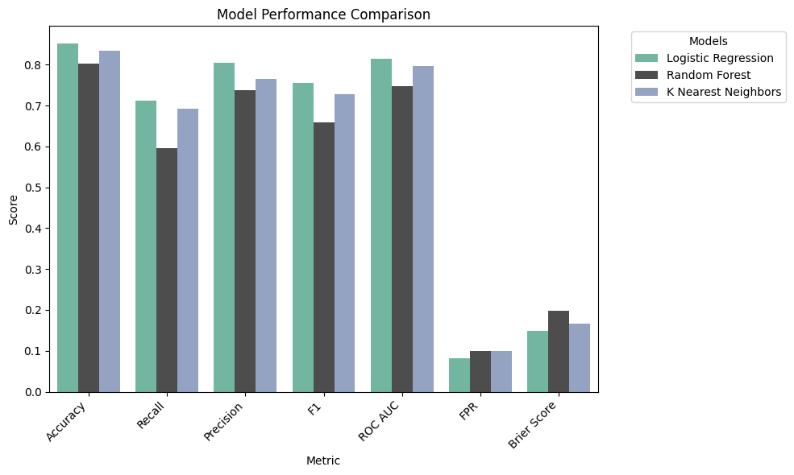

```python
plot_model_performance(ideal_metrics)
```

In this project, we explored multiple models to predict PCOS diagnosis based on clinical, demographic, and behavioral features. We tested our models under two conditions — one using all available features, and another using a feature-selected subset. In both cases, we compared Logistic Regression, Random Forest, and K-Nearest Neighbors using performance metrics like Accuracy, F1 Score, and ROC AUC.

Going forward, we plan to explore two main directions:

1. Refine the PCOS prediction model using top-ranked features. We plan to finalize a predictive model based on the most correlated features identified through our correlation heatmaps and visualizations. This will help us build a more interpretable and generalizable classifier.
2. Analyze feature importance and explore causal relationships. Using tools like permutation importance or SHAP values, we aim to understand which features most influence the model’s prediction. This could uncover deeper clinical insights into which symptoms are the strongest indicators of PCOS.